# EasyVisa Project

**Random Forest with class weights:**

```python
rf_wt = RandomForestClassifier(class_weight={0:0.33,1:0.67}, random_state=1)
rf_wt.fit(X_train,y_train)
```

```
RandomForestClassifier(class_weight={0: 0.33, 1: 0.67}, random_state=1)
```

```python
confusion_matrix_sklearn(rf_wt, X_train,y_train)
```

[output not shown]

```python
rf_wt_model_train_perf=model_performance_classification_sklearn(rf_wt, X_train,y_train)
print("Training performance \n",rf_wt_model_train_perf)
```

```
Training performance
    Accuracy  Recall  Precision   F1
0       1.0     1.0        1.0  1.0
```

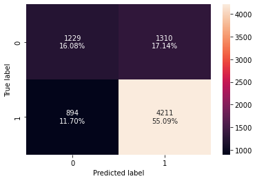

```python
confusion_matrix_sklearn(rf_wt, X_test,y_test)
```

```python
rf_wt_model_test_perf=model_performance_classification_sklearn(rf_wt, X_test,y_test)
print("Testing performance \n",rf_wt_model_test_perf)
```

```
Testing performance
    Accuracy    Recall  Precision        F1
0  0.711669  0.824878   0.762724  0.792584
```

- Using the class weight paramater does not improve the F1 score, nor does it help much in other measures.

**Tuning decision tree:**

```python
# Choose the type of classifier.
dtree_estimator = DecisionTreeClassifier(class_weight={0:0.33,1:0.67},random_state=1)

# Grid of parameters to choose from
parameters = {'max_depth': np.arange(2,10),
              'min_samples_leaf': [1, 2, 5, 7, 10],
              'max_leaf_nodes' : [2, 3, 5, 10,15],
              'min_impurity_decrease': [0.0001,0.001,0.01,0.1]
             }

# Type of scoring used to compare parameter combinations
scorer = metrics.make_scorer(metrics.recall_score)

# Run the grid search
grid_obj = GridSearchCV(dtree_estimator, parameters, scoring=scorer)
grid_obj = grid_obj.fit(X_train, y_train)

# Set the clf to the best combination of parameters
dtree_estimator = grid_obj.best_estimator_

# Fit the best algorithm to the data.
dtree_estimator.fit(X_train, y_train)
```

```
DecisionTreeClassifier(class_weight={0: 0.33, 1: 0.67}, max_depth=2,
                       max_leaf_nodes=2, min_impurity_decrease=0.0001,
                       random_state=1)
```

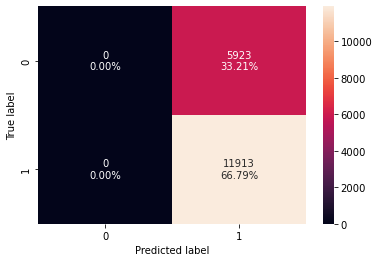

```python
confusion_matrix_sklearn(dtree_estimator, X_train,y_train)
```

```python
dtree_estimator_model_train_perf=model_performance_classification_sklearn(dtree_estimator, X_train,y_train)
print("Training performance \n",dtree_estimator_model_train_perf)
```

```
Training performance
    Accuracy  Recall  Precision        F1
0  0.667919     1.0   0.667919  0.800901
```

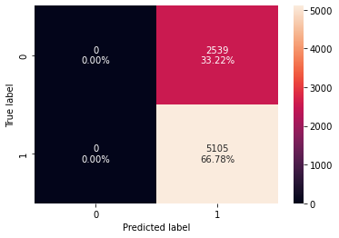

```python
confusion_matrix_sklearn(dtree_estimator, X_test,y_test)
```

```python
dtree_estimator_model_test_perf=model_performance_classification_sklearn(dtree_estimator, X_test, y_test)
print("Testing performance \n",dtree_estimator_model_test_perf)
```

```
Testing performance
    Accuracy  Recall  Precision        F1
0  0.667844     1.0   0.667844  0.800847
```

- Tuning the decision tree reduces overfitting and gives a bettter F1 score.
- Tuning gives a perfect recall.

**Tuning Bagging Classifier:**

```python
# grid search for bagging classifier
cl1 = DecisionTreeClassifier(class_weight={0:0.33,1:0.67},random_state=1)
param_grid = {'base_estimator':[cl1],
              'n_estimators':[5,7,15,37,50],
              'max_features': [0.7,0.8,0.9,1]
             }

grid = GridSearchCV(BaggingClassifier(random_state=1,bootstrap=True), param_grid=param_grid, scoring = 'recall', cv = 5)
grid.fit(X_train, y_train)

## getting the best estimator
bagging_estimator  = grid.best_estimator_
bagging_estimator.fit(X_train,y_train)
```

```
BaggingClassifier(base_estimator=DecisionTreeClassifier(class_weight={0: 0.33,
                                                                      1: 0.67},
                                                        random_state=1),
                  max_features=1, n_estimators=5, random_state=1)
```

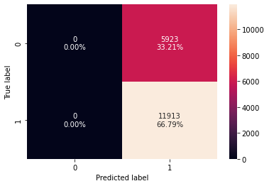

```python
confusion_matrix_sklearn(bagging_estimator, X_train,y_train)
```

```python
bagging_estimator_model_train_perf=model_performance_classification_sklearn(bagging_estimator, X_train,y_train)
print("Training performance \n",bagging_estimator_model_train_perf)
```

```
Training performance
    Accuracy  Recall  Precision        F1
0  0.667919     1.0   0.667919  0.800901
```

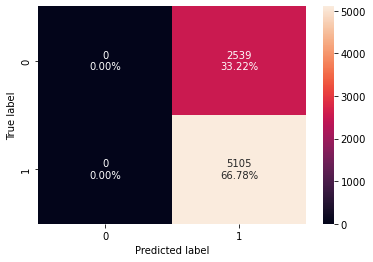

```python
confusion_matrix_sklearn(bagging_estimator, X_test,y_test)
```

```python
bagging_estimator_model_test_perf=model_performance_classification_sklearn(bagging_estimator, X_test, y_test)
print("Testing performance \n",bagging_estimator_model_test_perf)
```

```
Testing performance
    Accuracy  Recall  Precision        F1
0  0.667844     1.0   0.667844  0.800847
```

- Tuning helps the bagging classifier generalize well.
- The F1 score has improved and the recall is at 1.0.

**Tuning Random Forest:**

```python
# Choose the type of classifier.
rf_estimator = RandomForestClassifier(random_state=1)

# Grid of parameters to choose from
parameters = {
        "min_samples_leaf": np.arange(1, 6,1),
        "max_features": [0.7,0.9,'log2','auto'],
        "max_samples": [0.7,0.9,None],
}

# Run the grid search
grid_obj = GridSearchCV(rf_estimator, parameters, scoring='recall',cv=5)
grid_obj = grid_obj.fit(X_train, y_train)

# Set the clf to the best combination of parameters
rf_estimator = grid_obj.best_estimator_

# Fit the best algorithm to the data.
rf_estimator.fit(X_train, y_train)
```

```
RandomForestClassifier(max_features='log2', max_samples=0.7, min_samples_leaf=5,
                       random_state=1)
```

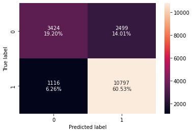

```python
confusion_matrix_sklearn(rf_estimator, X_train,y_train)
```

```python
rf_estimator_model_train_perf=model_performance_classification_sklearn(rf_estimator, X_train,y_train)
print("Training performance \n",rf_estimator_model_train_perf)
```

```
Training performance
    Accuracy    Recall  Precision        F1
0   0.79732  0.906321   0.812049  0.856599
```

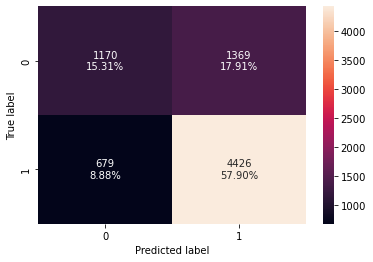

```python
confusion_matrix_sklearn(rf_estimator, X_test,y_test)
```

```python
rf_estimator_model_test_perf=model_performance_classification_sklearn(rf_estimator, X_test, y_test)
print("Testing performance \n",rf_estimator_model_test_perf)
```

```
Testing performance
    Accuracy    Recall  Precision       F1
0  0.732077  0.866993   0.763762  0.81211
```

**Gradient booster classifier:**

```
Training performance:
    Accuracy    Recall  Precision        F1
0   0.75157  0.877025   0.778888  0.825048
Testing performance:
    Accuracy    Recall  Precision      F1
0  0.737572  0.873066   0.766466  0.8163
```

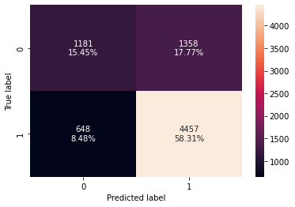

```python
#Fitting the model
gb_classifier = GradientBoostingClassifier(random_state=1)
gb_classifier.fit(X_train,y_train)

#Calculating different metrics
gb_classifier_model_train_perf=model_performance_classification_sklearn(gb_classifier,X_train,y_train)
print("Training performance:\n",gb_classifier_model_train_perf)
gb_classifier_model_test_perf=model_performance_classification_sklearn(gb_classifier,X_test,y_test)
print("Testing performance:\n",gb_classifier_model_test_perf)

#Creating confusion matrix
confusion_matrix_sklearn(gb_classifier,X_test,y_test)
```

- Using the gradient booster, the recall reaches 87% and the F1 score is ~81%.
- The model does not suffer from overfitting.

**Hyperparameter tuning on gradient booster:**

```python
# Choose the type of classifier.
gbc_tuned = GradientBoostingClassifier(init=AdaBoostClassifier(random_state=1),random_state=1)

# Grid of parameters to choose from
parameters = {
    "n_estimators": [100,150,200,250],
    "subsample":[0.8,0.9,1],
    "max_features":[0.7,0.8,0.9,1]
}

# Type of scoring used to compare parameter combinations
scorer = metrics.make_scorer(metrics.f1_score)

# Run the grid search
grid_obj = GridSearchCV(gbc_tuned, parameters, scoring=scorer,cv=5)
grid_obj = grid_obj.fit(X_train, y_train)

# Set the clf to the best combination of parameters
gbc_tuned = grid_obj.best_estimator_

# Fit the best algorithm to the data.
gbc_tuned.fit(X_train, y_train)
```

```
GradientBoostingClassifier(init=AdaBoostClassifier(random_state=1),
                           max_features=1, random_state=1, subsample=0.8)
```

```
Training performance:
    Accuracy    Recall  Precision        F1
0  0.736656  0.901872   0.752803  0.820622
Testing performance:
    Accuracy    Recall  Precision        F1
0  0.719519  0.889912   0.741714  0.809083
```

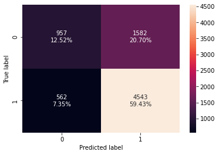

```python
#Calculating different metrics
gbc_tuned_model_train_perf=model_performance_classification_sklearn(gbc_tuned,X_train,y_train)
print("Training performance:\n",gbc_tuned_model_train_perf)
gbc_tuned_model_test_perf=model_performance_classification_sklearn(gbc_tuned,X_test,y_test)
print("Testing performance:\n",gbc_tuned_model_test_perf)

#Creating confusion matrix
confusion_matrix_sklearn(gbc_tuned,X_test,y_test)
```

- Tuning caused precision to decrease and therefore it is not very useful.

**XGBoost classifier:**

```
Training performance:
    Accuracy    Recall  Precision       F1
0  0.836735  0.924536   0.845475  0.88324
Testing performance:
    Accuracy    Recall  Precision        F1
0  0.723705  0.849167   0.763608  0.804118
```

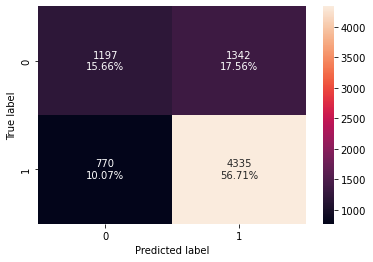

```python
#Fitting the model
xgb_classifier = XGBClassifier(random_state=1, eval_metric='logloss')
xgb_classifier.fit(X_train,y_train)

#Calculating different metrics
xgb_classifier_model_train_perf=model_performance_classification_sklearn(xgb_classifier,X_train,y_train)
print("Training performance:\n",xgb_classifier_model_train_perf)
xgb_classifier_model_test_perf=model_performance_classification_sklearn(xgb_classifier,X_test,y_test)
print("Testing performance:\n",xgb_classifier_model_test_perf)

#Creating confusion matrix
confusion_matrix_sklearn(xgb_classifier,X_test,y_test)
```

- The model does not generalize as well on the test data so it may be overfitting.
- The recall is at 84%.

**Hyperparameter tuning on xgboost classifier:**

```python
# Choose the type of classifier.
xgb_tuned = XGBClassifier(random_state=1, eval_metric='logloss')

# Grid of parameters to choose from
parameters = {
    "n_estimators": [10,30,50],
    "scale_pos_weight":[1,2,5],
    "subsample":[0.7,0.9,1],
    "learning_rate":[0.05, 0.1,0.2],
    "colsample_bytree":[0.7,0.9,1],
    "colsample_bylevel":[0.5,0.7,1]
}

# Type of scoring used to compare parameter combinations
scorer = metrics.make_scorer(metrics.f1_score)

# Run the grid search
grid_obj = GridSearchCV(xgb_tuned, parameters,scoring=scorer,cv=5)
grid_obj = grid_obj.fit(X_train, y_train)

# Set the clf to the best combination of parameters
xgb_tuned = grid_obj.best_estimator_

# Fit the best algorithm to the data.
xgb_tuned.fit(X_train, y_train)
```

```
XGBClassifier(base_score=None, booster=None, callbacks=None,
              colsample_bylevel=0.5, colsample_bynode=None,
              colsample_bytree=0.7, early_stopping_rounds=None,
              enable_categorical=False, eval_metric='logloss',
              feature_types=None, gamma=None, gpu_id=None, grow_policy=None,
              importance_type=None, interaction_constraints=None,
              learning_rate=0.2, max_bin=None, max_cat_threshold=None,
              max_cat_to_onehot=None, max_delta_step=None, max_depth=None,
              max_leaves=None, min_child_weight=None, missing=nan,
              monotone_constraints=None, n_estimators=10, n_jobs=None,
              num_parallel_tree=None, predictor=None, random_state=1, ...)
```

```
Training performance:
    Accuracy    Recall  Precision        F1
0   0.75028  0.903635   0.765049  0.828587
Testing performance:
    Accuracy    Recall  Precision        F1
0  0.728545  0.894221   0.748361  0.814815
```

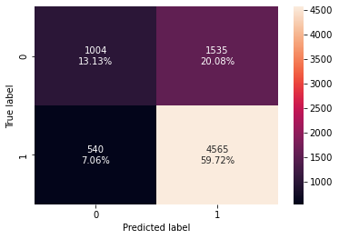

```python
# Calculating different metrics
xgb_tuned_model_train_perf=model_performance_classification_sklearn(xgb_tuned,X_train,y_train)
print("Training performance:\n",xgb_tuned_model_train_perf)
xgb_tuned_model_test_perf=model_performance_classification_sklearn(xgb_tuned,X_test,y_test)
print("Testing performance:\n",xgb_tuned_model_test_perf)

#Creating confusion matrix
confusion_matrix_sklearn(xgb_tuned,X_test,y_test)
```

## Will tuning the hyperparameters improve the model performance?

As demonstrated above, tuning hyperparameters reduced overfitting and increased performance for some models.

## Model Performance Comparison and Conclusions

```python
# training performance comparison on bagging models:c

models_train_comp_df = pd.concat(
    [dtree_model_train_perf.T,bagging_model_train_perf.T, bagging_wt_model_train_perf.T,rf_model_train_perf.T,
    rf_wt_model_train_perf.T,dtree_estimator_model_train_perf.T, bagging_estimator_model_train_perf.T,
     rf_estimator_model_train_perf.T],
    axis=1,
)
models_train_comp_df.columns = [
    "Decision Tree",
    "Bagging Classifier",
    "Weighted Bagging Classifier",
    "Random Forest Classifier",
    "Weighted Random Forest Classifier",
    "Decision Tree Estimator",
    "Bagging Estimator",
    "Random Forest Estimator"]
print("Training performance comparison:")
models_train_comp_df
```

```
Training performance comparison:
```

|  | Decision Tree | Bagging Classifier | Weighted Bagging Classifier | Random Forest Classifier | Weighted Random Forest Classifier | Decision Tree Estimator | Bagging Estimator | Random Forest Estimator |
| --- | --- | --- | --- | --- | --- | --- | --- | --- |
| Accuracy | 1.0 | 0.985591 | 0.983404 | 1.0 | 1.0 | 0.667919 | 0.667919 | 0.797320 |
| Recall | 1.0 | 0.986821 | 0.983380 | 1.0 | 1.0 | 1.000000 | 1.000000 | 0.906321 |
| Precision | 1.0 | 0.991565 | 0.991704 | 1.0 | 1.0 | 0.667919 | 0.667919 | 0.812049 |
| F1 | 1.0 | 0.989188 | 0.987524 | 1.0 | 1.0 | 0.800901 | 0.800901 | 0.856599 |

- Bagging classifier, weighted bagging classifier, random forest classifier, and weighted random forest classifier are all overfitting to the training data.
- Bagging estimator's precision is low.
- Random forest estimator appears to be fitting well on all performance measures with less risk of overfitting.

```python
# testing performance comparison on bagging models:

models_test_comp_df = pd.concat(
    [dtree_model_test_perf.T,bagging_model_test_perf.T, bagging_wt_model_test_perf.T,rf_model_test_perf.T,
    rf_wt_model_test_perf.T,dtree_estimator_model_test_perf.T, bagging_estimator_model_test_perf.T,
     rf_estimator_model_test_perf.T],
    axis=1,
)
models_test_comp_df.columns = [
    "Decision Tree",
    "Bagging Classifier",
    "Weighted Bagging Classifier",
    "Random Forest Classifier",
    "Weighted Random Forest Classifier",
    "Decision Tree Estimator",
    "Bagging Estimator",
    "Random Forest Estimator"]
print("Testing performance comparison:")
models_test_comp_df
```

```
Testing performance comparison:
```

|  | Decision Tree | Bagging Classifier | Weighted Bagging Classifier | Random Forest Classifier | Weighted Random Forest Classifier | Decision Tree Estimator | Bagging Estimator | Random Forest Estimator |
| --- | --- | --- | --- | --- | --- | --- | --- | --- |
| Accuracy | 0.650445 | 0.689953 | 0.681319 | 0.715725 | 0.711669 | 0.667844 | 0.667844 | 0.732077 |
| Recall | 0.728893 | 0.772576 | 0.754554 | 0.835651 | 0.824878 | 1.000000 | 1.000000 | 0.866993 |
| Precision | 0.742863 | 0.765379 | 0.765045 | 0.761786 | 0.762724 | 0.667844 | 0.667844 | 0.763762 |
| F1 | 0.735812 | 0.768961 | 0.759763 | 0.797011 | 0.792584 | 0.800847 | 0.800847 | 0.812110 |

```python
# importance of features in the tree building ( The importance of a feature is computed as the
#(normalized) total reduction of the criterion brought by that feature. It is also known as the Gini importance )

print (pd.DataFrame(rf.feature_importances_, columns = ["Imp"], index = X_train.columns).sort_values(by = 'Imp', ascending = False))
```

```
                                        Imp
no_of_employees                    0.252097
prevailing_wage_adjusted           0.248907
yr_of_estab                        0.211736
education_of_employee_High School  0.067188
has_job_experience_Y               0.044917
education_of_employee_Master's     0.034923
education_of_employee_Doctorate    0.018846
full_time_position_Y               0.015999
requires_job_training_Y            0.015683
continent_Europe                   0.015674
continent_Asia                     0.012213
region_of_employment_Midwest       0.011658
region_of_employment_West          0.010796
region_of_employment_Northeast     0.010266
continent_North America            0.010068
region_of_employment_South         0.009617
continent_South America            0.006706
continent_Oceania                  0.002706
```

```python
feature_names = X_train.columns
```

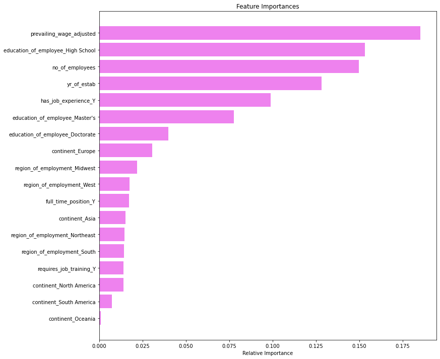

```python
importances = rf_estimator.feature_importances_
indices = np.argsort(importances)

plt.figure(figsize=(12,12))
plt.title('Feature Importances')
plt.barh(range(len(indices)), importances[indices], color='violet', align='center')
plt.yticks(range(len(indices)), [feature_names[i] for i in indices])
plt.xlabel('Relative Importance')
plt.show()
```

- The XGBoost classifier performs with hypertuning performs about the same as the random forest estimator in terms of the F1 score but does better on recall (89%).

## Actionable Insights and Recommendations

- The most important features to consider are as follows: prevailing_wage, education_of_employee, no_of_employees, and yr_of_estab.
- Continent and region_of_employment are not that impactful.
- Someone working in an industry with a high prevailing wage, Master's/Doctorate degree, is applying for a position at a company that is well established, and is applying at a company with a higher number of employees is much more likely to be certified than someone without these qualities.
- The XGBoost classifier with hypertuning appears to be the most useful model according to the F1 score and recall. Recall is particularly useful in this case because we do not want to deny an application that deserves to be certified.
- Additionally, it may be worth removing the continent column altogether so the model is not discriminatory according to ethnicity.